# Pathway Selection

James Dao

```r
# Load libraries
suppressPackageStartupMessages({
  library(here)
  library(EnsDb.Hsapiens.v86)
  library(DESeq2)
  library(pheatmap)
  library(tidyverse)
})

# Load raw count data and associated metadata
source(here("1_pathway_selection", "data", "get_data.R"))
load(here("1_pathway_selection", "data", "counts.Rdata"))
```

# Intro

We will analyse bulk RNA-Seq data (GSE101548) referenced by Prodromidou et al. (2020)<sup>1</sup>, following these rough steps:

- Perform DEG analysis with DESeq2
- Select significant over-/under-expressed genes and pass them to the [Enrichr browser tool](https://maayanlab.cloud/Enrichr/)
- From the Enrichr results, manually select any salient pathways possibly related to aging

# Data Sanity Check

We will sanity check the data we downloaded and processed by recreating some figures seen in the original paper.

```r
# Add cell grouping used by paper (mentioned in the description of fig. 1D)
metadata <- metadata %>%
  mutate(cell_group = case_when(
    cell_type == "Fetal fibroblast" ~ "Fibroblast",
    cell_type == "Adult - Primary skin" ~ "Fibroblast",
    cell_type == "Embryonic stem cell" ~ "HUES_iPSCs",
    cell_type == "Induced pluripotent stem cell" ~ "HUES_iPSCs",
    cell_type == "Neural progenitor cell" ~ "NPCs",
    cell_type == "neuron" ~ "Neurons"
  )) %>%   mutate(deg_group = case_when(
    source_name == "Skin" ~ "adult_primary_skin",
    source_name == "iPSCs" ~ "iPSCs",
    TRUE ~ "untested"
  ))

# Get gene symbols to convert from Ensembl IDs
ens2sym <- AnnotationDbi::select(
  EnsDb.Hsapiens.v86,
  keys = keys(EnsDb.Hsapiens.v86),
  columns = c("SYMBOL")
)

# Create DESeq data objects for further analysis
dds <- DESeqDataSetFromMatrix(
  countData = counts,
  colData = metadata,
  design = ~ deg_group
)
dds <- DESeq(dds, quiet = TRUE)

vsd <- vst(dds, blind = TRUE)
```

## Recreating Figure 1D

- We have decent distinct expression patterns and within-group uniformity
- However, compared to the original figure, our `HUES_iPSCs` and `Neurons` clusters seemed to be swapped
  - Possibly caused by using different parameters in underlying PCA algorithm
  - Most likely still the same plot, just shown at a different orientation about the 3rd (or higher) dimension

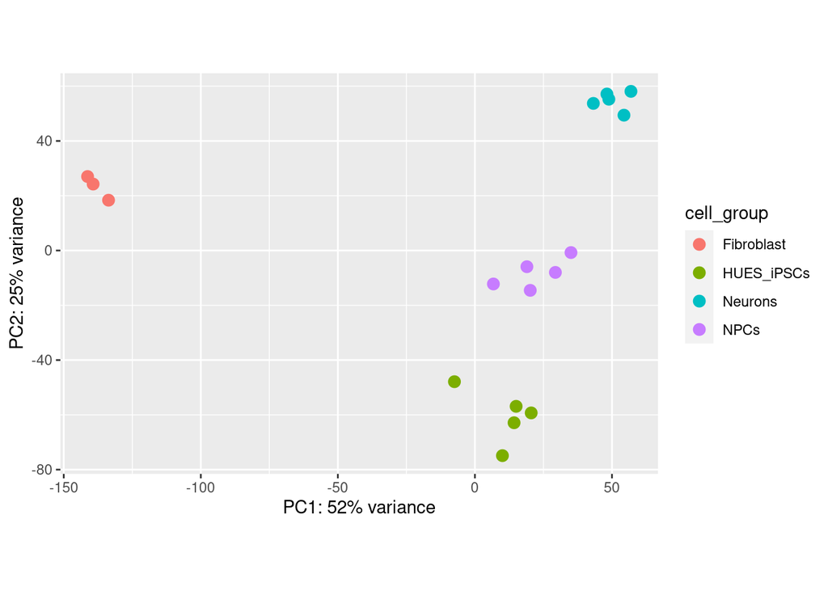

```r
pca_data <- plotPCA(
  vsd,
  intgroup = c("cell_group"),
  returnData = TRUE,
  ntop = 1000  # Paper says "top 1000 miRNAs with the highest variance across all samples"
)
percentVar <- round(100 * attr(pca_data, "percentVar"))

ggplot(pca_data, aes(x = PC1, y = PC2, color = cell_group)) +
  geom_point(size = 3) +
  xlab(paste0("PC1: ", percentVar[1], "% variance")) +
  ylab(paste0("PC2: ", percentVar[2], "% variance")) +
  coord_fixed()
```

## Recreating Figure 1G

Pretty much matches the original paper.

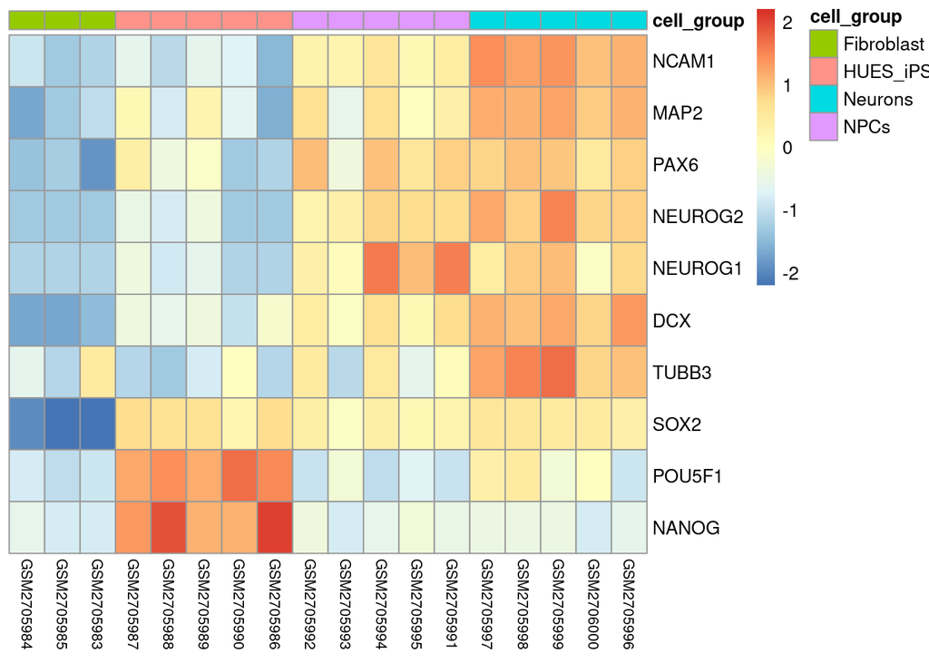

```r
# Use the same ordering as fig 1G in the original paper
colname_order <- c(
  "GSM2705984", "GSM2705985", "GSM2705983", "GSM2705987", "GSM2705988",
  "GSM2705989", "GSM2705990", "GSM2705986", "GSM2705992", "GSM2705993",
  "GSM2705994", "GSM2705995", "GSM2705991", "GSM2705997", "GSM2705998",
  "GSM2705999", "GSM2706000", "GSM2705996"
)

# Use selected genes from paper
neur_genes <- c(
  "NCAM1", "MAP2", "PAX6", "NEUROG2", "NEUROG1",
  "DCX", "TUBB3", "SOX2", "POU5F1", "NANOG"
)

rowname_order <- counts[matrixStats::rowSums2(counts) != 0, ] %>%
  as.data.frame() %>%
  rownames_to_column("GENEID") %>%
  left_join(ens2sym, by = "GENEID") %>%
  filter(SYMBOL %in% neur_genes) %>%
  arrange(match(SYMBOL, neur_genes)) %>%
  pull(GENEID)

pheatmap(
  assay(vsd)[rowname_order, colname_order],
  labels_row = neur_genes,
  annotation_col = select(metadata, cell_group),
  fontsize_col = 8,
  scale = "row",
  cluster_rows = FALSE,
  cluster_cols = FALSE
)
```

# Pathway Enrichment

## Computing Log2 Fold Changes

Expression levels (measured by log2FoldChange) are computed using `iPSCs_vs_adult_primary_skin`.

- `iPSCs` uses all 4 given samples
- `adult_primary_skin` uses 2 out of the 3 given fibroblast samples (fetal fibroblast sample is excluded)

Metadata link for convenience: https://www.ncbi.nlm.nih.gov/Traces/study/?acc=PRJNA394766&o=acc_s%3Aa

The datatable below shows the top 1000 DEGs by lowest adjusted p-value.  
Positive log fold changes means that a given gene is more greatly expressed in `iPSCs` than in `adult_primary_skin`.

```r
# Perform LFC shrinkage and join gene symbols
res_lfc <- lfcShrink(dds,
    coef = "deg_group_iPSCs_vs_adult_primary_skin",
    type = "apeglm", quiet = TRUE
  ) %>%
  as.data.frame() %>%
  rownames_to_column("GENEID") %>%
  left_join(ens2sym, by = "GENEID") %>%
  column_to_rownames("GENEID")

res_lfc %>%
  rownames_to_column("GENEID") %>%
  select(SYMBOL, log2FoldChange, padj) %>%
  slice_min(padj, n = 1000) %>%
  mutate(log2FoldChange = signif(log2FoldChange, 4)) %>%
  mutate(padj = signif(padj, 4)) %>%
  DT::datatable()
```

|  | SYMBOL | log2FoldChange | padj |
| --- | --- | --- | --- |
| 1 | C11orf68 | -2.423 | 2.115e-57 |
| 2 | STAT1 | -3.821 | 5.297e-53 |
| 3 | CTSB | -5.279 | 5.297e-53 |
| 4 | CD59 | -4.76 | 5.866e-50 |
| 5 | MFAP5 | -10.59 | 2.209e-44 |
| 6 | RFX8 | -6.662 | 2.531e-39 |
| 7 | CYB5R3 | -3.248 | 9.371e-36 |
| 8 | CDC42EP3 | -4.626 | 4.81e-32 |
| 9 | SNX9 | -3.658 | 1.499e-31 |
| 10 | C12orf75 | -4.82 | 2.84e-29 |

[output cut: 990 more lines]

## Enrichr & Pathway Selection

(Interesting aging pathways were selected manually.)

Over-expressed: https://maayanlab.cloud/Enrichr/enrich?dataset=777cbfdac04766bc95989ed6e56706bd

- Used DEGs with p.adj < 0.01 and positive log2FoldChange
- Mostly looks like pathways related to early stage cell cycles and differentiation

Under-expressed: https://maayanlab.cloud/Enrichr/enrich?dataset=ad94f7930a57b737afa32ad0063b7f19

- Used DEGs with p.adj < 0.01 and negative log2FoldChange
- If we click “Ontologies” -> “GO Biological Process 2021” -> “Table” and sort by Adjusted p-value, we see:
  - cellular response to starvation (GO:0009267)
  - cellular response to amino acid starvation (GO:0034198)
  - positive regulation of transcription from RNA polymerase II promoter in response to stress (GO:0036003)
  - ATF6-mediated unfolded protein response (GO:0036500)
  - response to amino acid starvation (GO:1990928)
  - cellular response to oxidative stress (GO:0034599)
  - response to endoplasmic reticulum stress (GO:0034976)
  - macroautophagy (GO:0016236)
  - regulation of autophagy (GO:0010506)

An interesting one is “ATF6-mediated unfolded protein response” which has OR=23.41 where most other pathways of single digit OR

```r
# Get overexpressed gene symbols for Enrichr
# res_lfc %>%
#   drop_na() %>%
#   filter(padj < 0.01) %>%
#   filter(log2FoldChange > 0) %>%
#   select(SYMBOL) %>%
#   write_csv("overexp_genelist.txt", quote = "none", col_names = FALSE)

# Get underexpressed gene symbols for Enrichr
# res_lfc %>%
#   drop_na() %>%
#   filter(padj < 0.01) %>%
#   filter(log2FoldChange < 0) %>%
#   select(SYMBOL) %>%
#   write_csv("underexp_genelist.txt", quote = "none", col_names = FALSE)
```

# References

1.

Prodromidou K, Vlachos IS, Gaitanou M, Kouroupi G, Hatzigeorgiou AG, Matsas R. MicroRNA-934 is a novel primate-specific small non-coding RNA with neurogenic function during early development. *eLife*. 2020;9. doi:10.7554/elife.50561